# Impact of Google Translation Project on Telugu Wikipedia

Arjuna Rao C

June 22, 2015

## Raw data and preprocessing

Raw data for this project comes from the following sources.

### Wikipedia Editing statistics

- https://stats.wikimedia.org/EN/TablesWikipediaTE.htm From this, extract the table Monthly counts & Quarterly rankings: May 2015 into a spreadsheet. Delete the quarterly portion, update the column headings to incorporate the details from the heading rows

### Wikipedia page view information

### Page requests for specific pages

- http://stat.grok.se gives pageviews for a specifc month
- Make use of script updatepvdata.R to obtain pageviews for a set of articles in a month.
- Input file should have header page_title and then one page name without quotes and with spaces transformed to underscore per line.
- This gives the total page_requests and the month specification. for details see the script
- Usage: updatepvdata(“te”,“”,“”,“”)

### Identifying Featured article pages

The talk pages of featured articles are gathered into a category called “ఈ_వారం_వ్యాసాల_చర్చలు_-_%“. Use this information to get the list of articles and their featured year, week information. http://quarry.wmflabs.org/query/3556

### Page requests for the entire wiki

https://stats.wikimedia.org/EN_India/TablesPageViewsMonthlyMobile.htm Specifically do the following for non mobile normalized views and mobile normalized views. As the html page is populated by a script, the information is difficult to extract directly. Copy paste page requests table to a spreadsheet and take out the column corresponding to Telugu language. Then extract the relevant number.

Then combine the page requests information into a common data frame. Alternately combined normalised page requests information can be obtained similarly and used when analysing the total page views.

## Data processing

### for gtp language wikipedia plots.

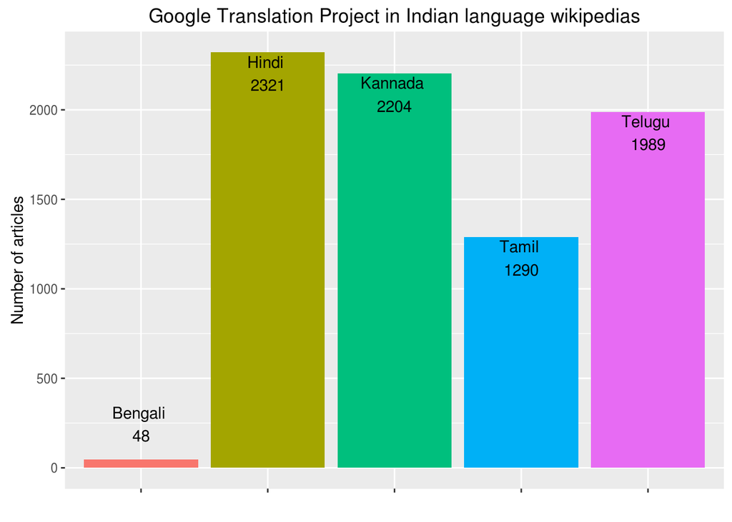

```r
library(ggplot2)
gtplang<-read.csv("data/gtplang.wsv",header=TRUE,sep="\t")
g<-ggplot(gtplang,aes(Wikipedia,GTP.articles,fill=Wikipedia))+geom_bar(stat="identity")+geom_text(label=paste(gtplang$Wikipedia,gtplang$GTP.articles,sep="\n"),vjust=c(rep(1.1,4),-0.5))+labs(x=" ",y="Number of articles",title="Google Translation Project in Indian language wikipedias")+  scale_colour_manual(values=cbPalette)+theme(legend.position="none",axis.text.x=element_blank())
g
```

###Key Editing statistics

```r
library(ggplot2)
library(reshape2)
source("src/convert wiki stats to numbers.R")
ws<-prepwstats()
mindex<-c(as.Date("2007-06-15"),as.Date("2008-06-15"),as.Date("2009-06-15"),as.Date("2010-06-15"),as.Date("2011-06-15"),as.Date("2012-06-15"))
cindex<-c("month","wikipedians_tot","db_size_words_M")
wsgtp<-ws[ws$month %in% mindex,cindex]
print(wsgtp)
```

```
##         month wikipedians_tot db_size_words_M
## 34 2012-06-15             506            13.8
## 46 2011-06-15             428            12.8
## 58 2010-06-15             348             6.7
## 70 2009-06-15             281             3.6
## 82 2008-06-15             224             2.5
## 94 2007-06-15             103             1.3
```

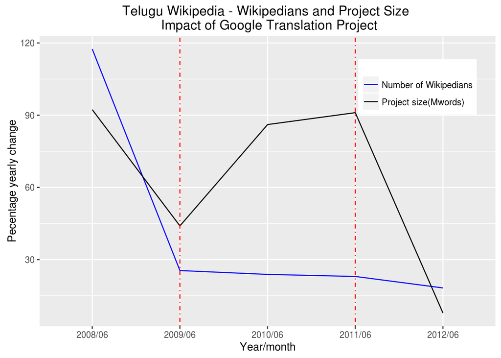

```r
source("src/pctcompute.R")
wspct<-as.data.frame(pctcompute(wsgtp))
wspct$month<-wsgtp$month
wspct<-wspct[-dim(wsgtp)[1],]
wspctm<-melt(wspct,id.vars="month",measure.vars=c("wikipedians_tot","db_size_words_M"))
g<-ggplot(wspctm,aes(as.factor(strftime(month,"%Y/%m")),value,group=variable))+
  geom_line(aes(color=variable))+labs(x="Year/month",y="Pecentage yearly change",title="Telugu Wikipedia - Wikipedians and Project Size \n Impact of Google Translation Project")+
  geom_vline(xintercept=2,color="red",linetype=4)+geom_vline(xintercept=4,color="red",linetype=4)+
  scale_colour_manual(name="",values=c("blue","black"),
      breaks=c("wikipedians_tot", "db_size_words_M"),
      labels=c("Number of Wikipedians", "Project size(Mwords)"))+
  theme(legend.justification=c(0.0,0.0), legend.position=c(0.68,0.7))
g
```

### Page views

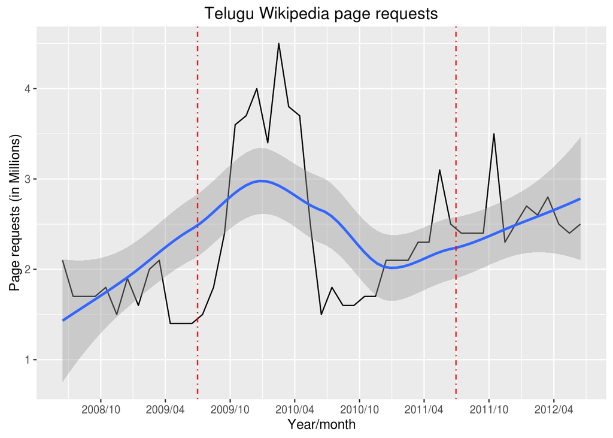

```r
source("src/tepvplot.R")
g<-plot_gtp_pr()
g
```

### Popularity

```r
#GTP page requests total
gtppr201403<-read.csv("data/gtppr201403.wsv",header=TRUE,sep=" ")
sum(gtppr201403$page_requests)
```

```
## [1] 107424
```

```r
#non GTP featured article page requests total
falpr201403<-read.csv("data/falpr201403.wsv",header=TRUE,sep=" ")
sum(falpr201403$page_requests)
```

```
## [1] 66805
```

### Popularity of bot created pages

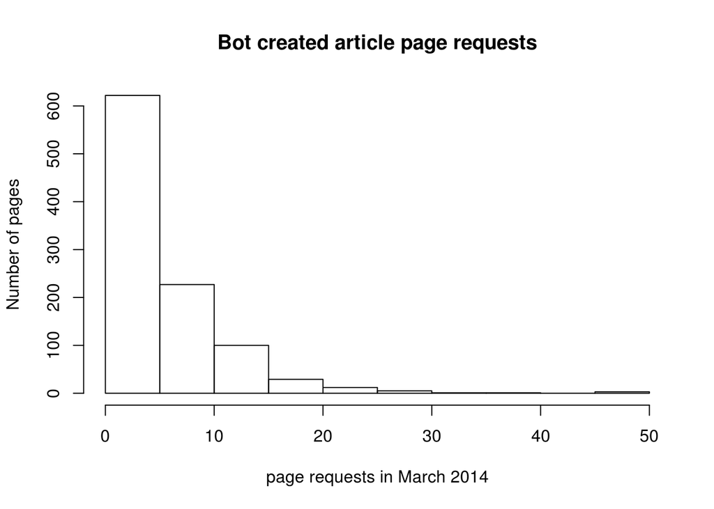

```r
vilsamp1pr<-read.csv("data/vilsamp1pr.csv",header=TRUE,sep=" ")
hist(vilsamp1pr$page_requests,main="Bot created article page requests",ylab="Number of pages",xlab="page requests in March 2014")
```

```r
# mean and sd of 1000 samples of bot created pages
mn<-mean(vilsamp1pr$page_requests)
sd<-sd(vilsamp1pr$page_requests)
cat("mean:",mn,"standard deviation:",sd,sep=" ")
```

```
## mean: 5.546 standard deviation: 5.639298
```

```r
#95% Confidence intervals for mean
cat("95% confidence interval for mean:")
```

```
## 95% confidence interval for mean:
```

```r
mn+c(-1,1)*qt(0.975,999)*sd(vilsamp1pr$page_requests)/sqrt(1000)
```

```
## [1] 5.196055 5.895945
```

## References

1. http://stat.grok.se for page requests in any given month for an article
2. http://quarry.wmflabs.org for an easy to use and share query interface for wikipedia
3. http://stats.wikimedia.org for wikipedia editing statistics